# Glyphs, Frames, and Scales

## Glyphs and Data

In its original sense, in archeology, a glyph is a carved symbol.

Heiro**glyph**

Mayan **glyph**

[figure not shown]

## Data Glyph

### A data glyph is also a mark, e.g.

The features of a data glyph encodes the value of variables.

See: *http://docs.ggplot2.org/current/*

## Data Glyph Properties: Aesthetics

Aesthetics are **visual properties** of a glyph.

- Aesthetics for points: location (x and y), shape, color, size, transparency

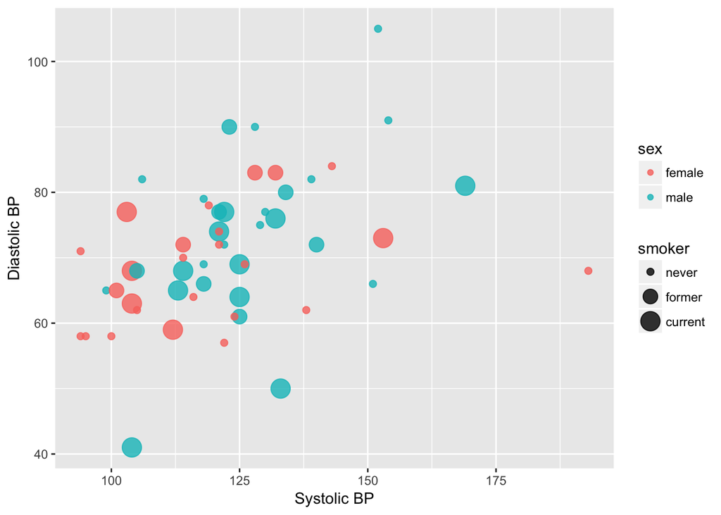

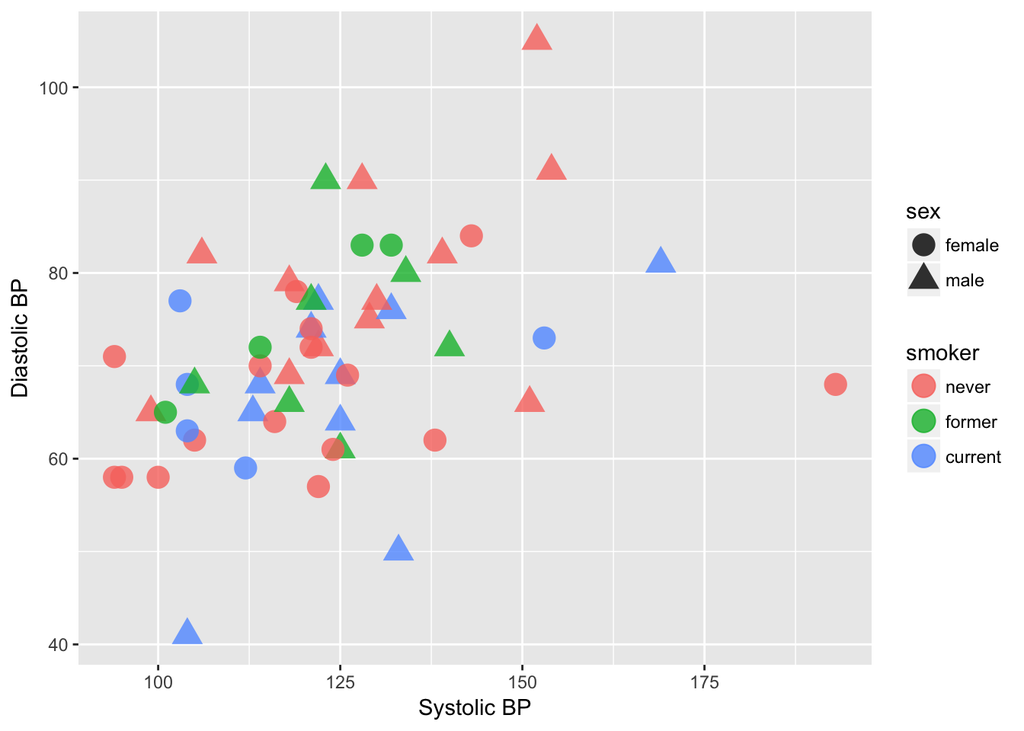

- Each glyph has its own set of aesthetics.

## Why “Aesthetic”?

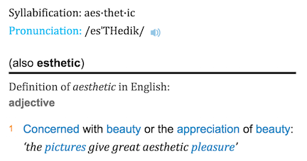

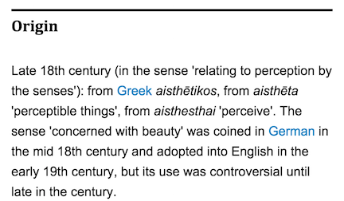

## Some Graphics Components

**glyph**

The basic graphical unit that represents one case. Other terms used include *mark* and *symbol*.

**aesthetic**

a visual property of a glyph such as position, size, shape, color, etc.

- may be **mapped** based on data values: `sex -> color`
- may be **set** to particular non-data related values: `color is black`

**scale**

A mapping that translates data values into aesthetics.

- example: male -> blue; female -> pink

**frame**

The position scale describing how data are mapped to x and y

**guide**

An indication for the human viewer of the scale. This allows the viewer to translate aesthetics back into data values.

- Examples: x- and y-axes, various sorts of legends

## Scales

The relationship between the variable value and the value of the aesthetic the variable is mapped to.

- Systolic Blood Pressure (SBP) has units of mmHg (millimeters of mercury)
- Position on the x-axis measured in distance, e.g. inches.

The conversion from SBP to position is a *scale*.

- Smoker is “never”, “former”, “current”
- Color is red, green, blue, …

The conversion from Smoker to color is a *scale*.

## Guides

Guide: an indication to a human viewer of what the scale is. Example:

- Axis ticks and numbers

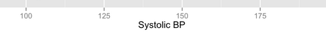

- Legends

[output not shown]

- Labels on faceted graphics

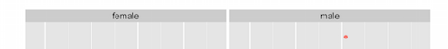

## Facets – using x and y twice

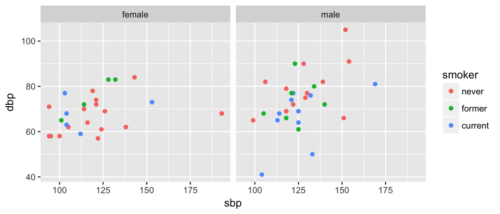

- x is determined by `sbp` and `sex`
- basically a separate frame for each `sex`

## Designing Graphics

Graphics are designed by the human expert (you!) in order to reveal information that’s latent in the data.

#### Design choices

- What kind of glyph, e.g. scatter, density, bar, … many others
- What variables constitute the frame. And some details:
  - axis limits
  - logarithmic axes, etc.
- What variables should be mapped to other aesthetics of the glyph.
- Whether to facet and with what variable.

More details, …, e.g. setting of aesthetics to constants

## Good and Bad Graphics

Remember …

> Graphics are designed by the human expert (you!) in order to reveal information that’s latent in the data.

Your choices depend on what information you want to reveal and convey.

Learn by reading graphics and determining which ways of arranging thing are better or worse.

A basic principle is that a graphic is about *comparison*. Good graphics make it easy for people to perceive things that are similar and things that are different. Good graphics put the things to be compared “side-by-side”, that is, in perceptual proximity to one another.

## Perception and Comparison

In roughly descending order of human ability to compare nearby objects:

1. Position
2. Length
3. Area
4. Angle
5. Shape (but only a very few different shapes)
6. Color

## Count the ways this graphic is bad

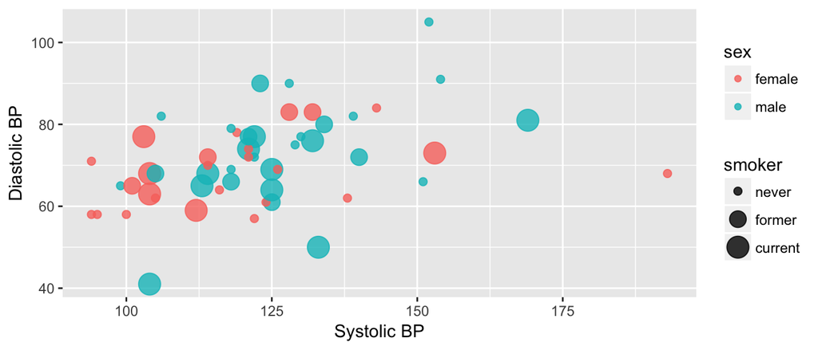

## Glyph-Ready Data

Glyph-ready data has this form:

- There is one row for each glyph to be drawn.
- The variables in that row are mapped to aesthetics of the glyph (including position)

**Glyph-ready data**

```
##   sbp dbp    sex  smoker
## 1 129  75   male   never
## 2 105  62 female   never
## 3 122  72   male   never
## 4 128  83 female  former
## 5 123  90   male  former
## 6 122  77   male current
```

**Mapping of data to aesthetics**

```
   sbp -> x
   dbp -> y
smoker -> color
   sex -> shape
```

Scales determine details of  
`data -> aesthetic` translation

## Layers – building up complex plots

Each layer may have its own data, glyphs, aesthetic mapping, etc.

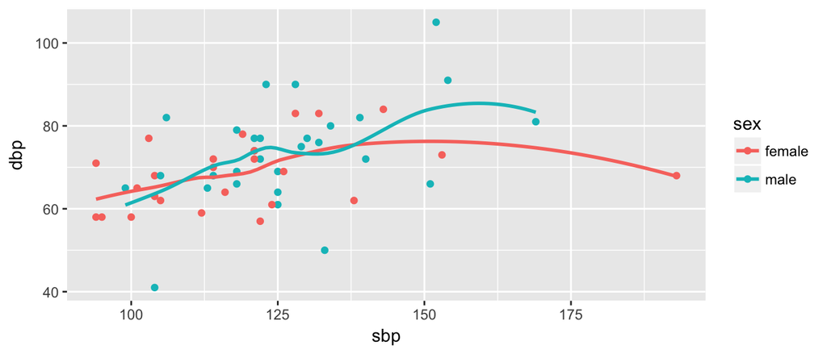

- one layer has points
- another layer has the curves

## Stats: Data Transformations

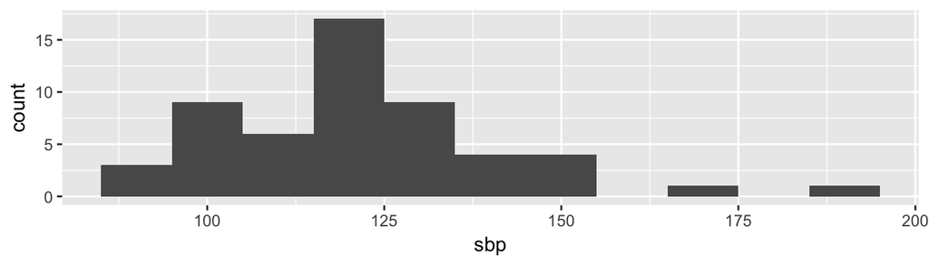

- What are the glyphs, aesthetics, etc. for this plot?
- How is the data for this plot related to the “raw” data?

```
##   sbp dbp    sex smoker
## 1 129  75   male  never
## 2 105  62 female  never
## 3 122  72   male  never
## 4 128  83 female former
```

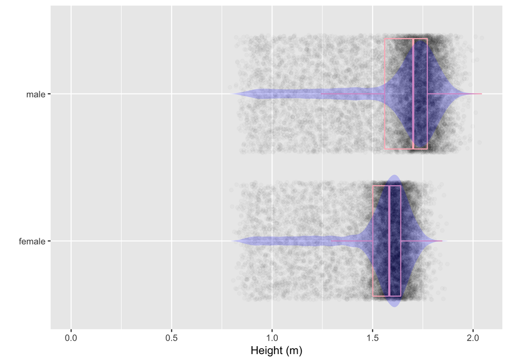

## What’s Next

1. **Eye-training**
   - recognize and describe glyphs, aesthetics, scales, etc.
   - identify data required for a plot
2. **Data wrangling**
   - get data into glyph-ready format (`dplyr`, `tidyr`)
3. **Graphics construction**
   - start with: map variables to aesthetics interactively with `scatterGraphHelper()`, `barGraphHelper()`, `densityGraphHelper()`
   - move on to: describe data, glyphs, aesthetics, etc. to R using `ggplot2`